# Aula 0 - Instalação da plataforma R

Olá pessoal, sejam bem-vind@s

Nessa aula iremos instalar a plataforma R que será usada durante o curso. Você poderá executar as atividades dessa aula por conta própria, antes do começo do curso. É recomendável que você tente executar a instalação antes do curso para detectar possíveis problemas e evitar atrasos que prejudiquem seu acompanhamento. Caso não consiga instalar ou executar o R, você poderá utilizar o RStudio Cloud, uma versão *online*. O acesso ao RStudio Cloud está descrito no fim desta aula. Também é recomendável que você faça o seu registro no RStudio Cloud com antecedência.

### Afinal, o que é o R?

O [R](https://www.r-project.org/) é um *software* gratuito que foi especialmente idealizado para estatística computacional e apresentação gráfica. Esse *software* funciona através de “linhas de comando”, ou seja, instruções escritas para o computador executar. Essas instruções devem ser escritas numa linguagem de programação, de mesmo nome que o *software*, R. Ao longo deste minicurso, nós iremos aprender a “falar” na linguagem de programação R para que o computador possa entender nossas instruções.

### Quem criou o R?

A plataforma R foi inicialmente desenvolvida por **R**obert Gentleman and **R**oss Ihaka (R & R), e atualmente é mantida por uma comunidade de programadores, o [*R Development Core Team*](https://www.r-project.org/contributors.html). Esses programadores não ganham nada por esse trabalho. Portanto, se você utilizar o R, cite essa comudidade de programadores (R Development Core Team, ANO).

### Quem sustenta o R?

A plataforma e todas as suas extensões são armazenadas em computadores ao redor do mundo, ou seja, servidores. A manutenção dessa rede de computadores é financiada por [doadores](https://www.r-project.org/foundation/donors.html). Qualquer um pode fazer [doações](https://www.r-project.org/foundation/donations.html).

### Como baixar o R?

A plataforma R está disponível no CRAN (*Comprehensive R Archive Network*). Para baixar, clique [aqui](https://cran.r-project.org/); escolha a opção referente ao sistema operacional do seu computador (e.g. Windowns, Linux, mcOS); escolha a opção *install R for the first time*; clique em *Download R 4.1.0* (ou a versão mais atual disponível). Com isto, um arquivo .exe será baixado na pasta de *downloads* do seu computador (ou na pasta designada como tal).

### Instalação do R

Execute o arquivo .exe que foi baixado (e.g. R-4.1.0-win.exe). Escolha a lingua de preferência (e.g. português Brasil); aceite os termos de uso; escolha a pasta para instalação do software (e.g. C:/Program Files/R/R-4.1.0); escolha a instalação padrão (*standard*). Ao final do processo, fica a seu critério criar um atalho (*shortcut*) do R na sua área de trabalho.

Se tudo deu certo, você será capaz de abrir a plataforma R no seu computador. Para isso, procure pelo R nos seus programas ou clique no atalho criado na sua área de trabalho. A interface da plataforma será semelhante à seguinte:

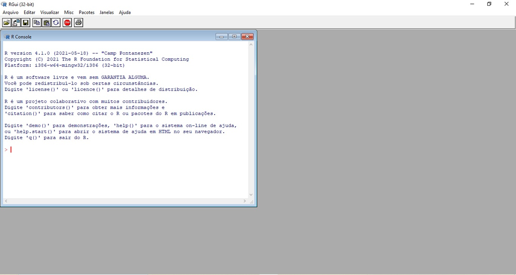

### Opcional: R Studio

A interface do R pode parecer pouco amigável, principalmente para usuários novos. Pensando nisso, a empresa RStudio desenvolveu uma IDE (*Integrated Development Environment*), o [RStudio](https://www.rstudio.com/). O RStudio facilita a utilização do R, ajudando o usuário a programar e fornecendo ferramentas adicionais de compartilhamento e visualização. Para baixar o RStudio, clique [aqui](https://www.rstudio.com/products/rstudio/download/); escolha a opção gratuíta (*free*); e um arquivo .exe será baixado em seu computador.

A instalação do RStudio requer que o R esteja instalado no seu computador. Execute o arquivo .exe (e.g. RStudio-1.4.1106.exe); escolha as opções padrões. Fica a seu critério criar um atalho na sua área de trabalho.

Se tudo deu certo, você será capaz de abrir o RStudio no seu computador. A interface do RStudio será semelhante à seguinte:

[figure not shown]

### Opcional: RStudio Cloud

Você pode estar com um computador com memória cheia, que talvez não suporte o R ou o RStudio. Isso não será um impedimento para que você acompanhe o curso. Existe uma opção *online* do RStudio, o [RStudio Cloud](https://rstudio.cloud/). Para ter acesso ao RStudio Cloud, faça seu registro aqui. Feito o registro, faça *login* na sua conta. A primeira página será a área dos seus projetos (*Your Workspace*); clique em novo projeto (*New Project*) para carregar a interface do RStudio *online*. Se tudo deu certo, você terá acesso a uma página semelhante a essa:

[figure not shown]

### Dificuldades?

Se ao longo desta aula você não conseguiu instalar/executar o R ou acessar o RStudio Cloud, por favor, entre em contato comigo (eduardo.k.nery@gmail.com).